# German Credit

Keaton Spiller, Winter 2022, STAT 387

2/24/2022

Report

Conceptual

1. Perform an exploratory analysis of data.

```
[1]  Default : 0 (no) and 1 (yes)                                      (qualitative)

[2]  checkingstatus1: Status of existing checking account              (qualitative)

[3]  duration: Duration in month                                       (numerical)

[4]  history: Credit history                                           (qualitative)

[5]  purpose: 1 of 10 things                                           (qualitative)

[6]  amount: Credit amount                                             (numerical)

[7]  savings:   Savings account/bonds                                  (qualitative)

[8]  employ: Present employment since                                  (qualitative)

[9]  installment: Installment rate in percentage of disposable income  (numerical)

[10] status: Personal status and sex                                   (qualitative)

[11] others: Other debtors / guarantors                                (qualitative)

[12] residence: Present residence since                                (numerical)

[13] property: Type of Property                                        (qualitative)

[14] age: Age in years                                                 (numerical)

[15] otherplans: Other installment plans                               (qualitative)

[16] housing: 3 types of housing                                       (qualitative)

[17] cards: Number of existing credits at this bank                    (numerical)

[18] job: type of job                                                  (qualitative)

[19] liable: Number of people being liable to provide maintenance for  (numerical)

[20] tele: none or yes                                                 (qualitative)

[21] foreign: yes or no                                                (qualitative)

Qualitative {14 categorical}: Default, checkingstatus1, history, purpose, savings, employ, status, others, property, otherplans, housing, job, tele, foreign

Numeric {7 Numerical}: duration, amount, installment, residence, age, cards, liable
```

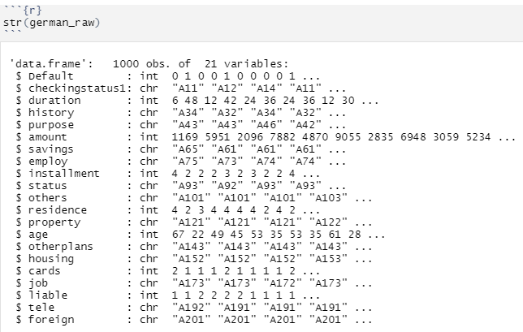

```
Placing the qualitative variables into factor form with as.factor()
```

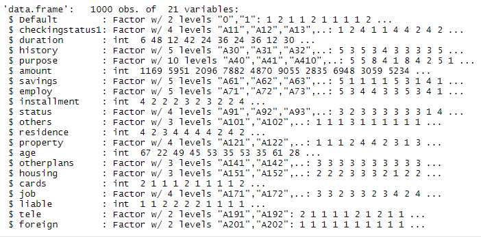

```
Interesting plots of variable exploration
```

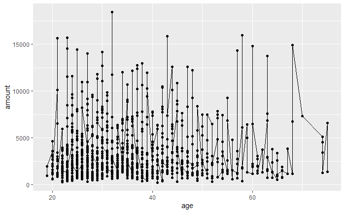

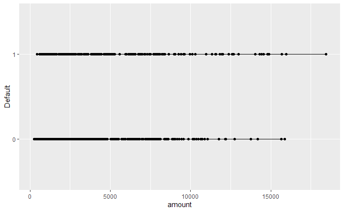

2. Build a reasonably “good” logistic regression model for these data. There is no need to explore interactions. Carefully justify all the choices you make in building the model.

[output not shown]

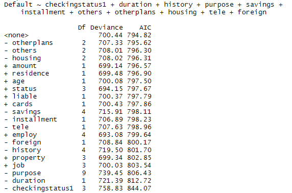

[output not shown]

3. Write the final model in equation form. Provide a summary of estimates of the regression coefficients, the standard errors of the estimates, and 95% confidence intervals of the coefficients. Interpret the estimated coefficients of at least two predictors. Provide training error rate for the model.

```
Page 135 section {4.3}
```

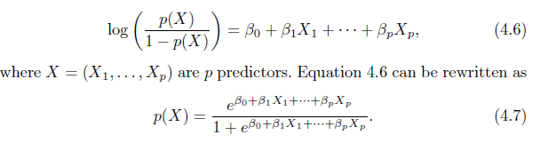

```
X is a matrix with 12 variables checkingstatus1 + duration + history + purpose + savings + installment + others + age + otherplans + housing + tele + foreign

logistic model Summary of regression coefficients and standard errors of the estimates
```

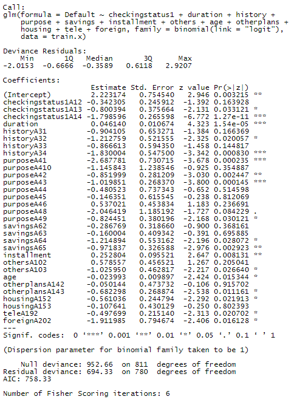

```
95% confidence intervals
```

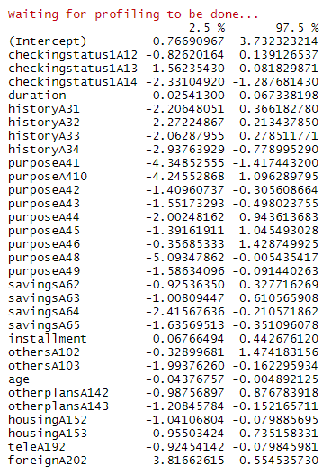

[output not shown]

4. Fit a KNN with K chosen optimally using test error rate. Report error rate, sensitivity, specificity, and AUC for the optimal KNN based on the training data. Also, report its estimated test error rate.

```
K optimal test error rate = 11

train error rate = 0.2413793

train sensitivity = 0.9525424

train Specificity = 0.2432432

train AUC = 0.7828218

test error rate = 0.3829787
```

5. Repeat (d) using LDA.

```
train error rate = 0.4248768

train sensitivity = 0.9135593

train Specificity = 0.5135135

train AUC = 0.8352497

test error rate = 0.3244681
```

6. Repeat (d) using QDA.

```
train error rate = 0.4889163

train sensitivity = 0.7661017

train Specificity = 0.8063063

train AUC = 0.8477248

test error rate = 0.393617
```

7. Compare the results in (b), (d)-(f). Which classifier would you recommend? Justify your answer.

Results training on train data and testing on train data

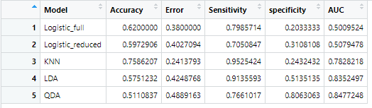

Results training on train data and testing on test data

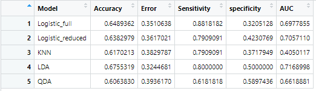

```
Based on the results I would recommend LDA, with the highest accuracy ~ 0.67 and lowest error rate ~ 0.32 on the test data.
Although KNN is the highest tested on train data, it doesn't do a good job accounting for unknown data (test data) and it's not the best model to choose.

Therefore LDA is the best model for predicting Default given the reduced variable selection
```

Additional notes

Cross Validation for model selection?

```
LOOCV:
more Bias,less Variance

K-Fold:
less Bias, > Variance
```

Ridge or Lasso For variable selection?

```
Ridge:

L2 Selection

Small coefficients

Lasso:

L1 Selection

Large coefficients (Sparcity)
```

chi square test of association is more accurate for logistic regression variable selection ( Not Taught in this class)

```
anova(chi square test)
```

## R Code

```r
rm(list=ls())
```

```r
set.seed(1)
library(bookdown)# load the libraries
library(dplyr)
library(broom)
library(faraway)
library(ellipse)
library(rstudioapi)
library(lmtest)
library(simex)
library(ggplot2)
library(lars)
library(MASS)
library(pls)
library(olsrr)
library(leaps)
library(matlib)
library(olsrr)
library(ggplot2)
library(lattice)
library(class)
library(MASS)
library(ISLR2)
library(boot)
library(ISLR2)
library(class)
library(e1071)
library(gam)
library(glmnet)
library(Amelia)
library(caret)
library(pROC)
library(ROCR)
```

1. exploratory analysis

```r
german_raw <-  read.csv(file = "germancredit.csv", header = TRUE)
german <- german_raw
head(german_raw,5)
```

```r
missmap(german, main = "Missing values vs observed")
```

```r
any(is.na(german_raw))
```

```r
str(german_raw)
```

```r
german$Default <- as.factor(german_raw$Default)
german$checkingstatus1 <- as.factor(german_raw$checkingstatus1)
german$history <- as.factor(german_raw$history)
german$purpose <- as.factor(german_raw$purpose)
german$savings <- as.factor(german_raw$savings)
german$employ <- as.factor(german_raw$employ)
german$status <- as.factor(german_raw$status)
german$others <- as.factor(german_raw$others)
german$property <- as.factor(german_raw$property)
german$otherplans <- as.factor(german_raw$otherplans)
german$housing <- as.factor(german_raw$housing)
german$job <- as.factor(german_raw$job)
german$tele <- as.factor(german_raw$tele)
german$foreign <- as.factor(german_raw$foreign)
str(german)
```

```r
plot(german[1:10])
```

```r
plot(german[11:21])
```

```r
plot(german[1:5])
```

```r
plot(german[6:10])
```

```r
plot(german[11:15])
```

```r
plot(german[16:21])
```

```r
colnames <-  colnames(german)
colnames
```

```r
ggplot(data=german, aes(x=Default, y=amount), x=Default, y=amount)+
  geom_line()+
  geom_point()
```

```r
ggplot(data=german, aes(x=checkingstatus1, y=amount), x=checkingstatus1, y=amount)+
  geom_line()+
  geom_point()
```

```r
ggplot(data=german, aes(x=duration, y=amount), x=duration, y=amount)+
  geom_line()+
  geom_point()
```

```r
ggplot(data=german, aes(x=history, y=amount), x=history, y=amount)+
  geom_line()+
  geom_point()
```

```r
ggplot(data=german, aes(x=purpose, y=amount), x=purpose, y=amount)+
  geom_line()+
  geom_point()
```

```r
ggplot(data=german, aes(x=savings, y=amount), x=savings, y=amount)+
  geom_line()+
  geom_point()
```

```r
ggplot(data=german, aes(x=employ, y=amount), x=employ, y=amount)+
  geom_line()+
  geom_point()
```

```r
ggplot(data=german, aes(x=installment, y=amount), x=installment, y=amount)+
  geom_line()+
  geom_point()
```

```r
ggplot(data=german, aes(x=status, y=amount), x=status, y=amount)+
  geom_line()+
  geom_point()
```

```r
ggplot(data=german, aes(x=others, y=amount), x=others, y=amount)+
  geom_line()+
  geom_point()
```

```r
ggplot(data=german, aes(x=residence, y=amount), x=residence, y=amount)+
  geom_line()+
  geom_point()
```

```r
ggplot(data=german, aes(x=property, y=amount), x=property, y=amount)+
  geom_line()+
  geom_point()
```

```r
ggplot(data=german, aes(x=age, y=amount), x=age, y=amount)+
  geom_line()+
  geom_point()
```

```r
ggplot(data=german, aes(x=otherplans, y=amount), x=otherplans, y=amount)+
  geom_line()+
  geom_point()
```

```r
ggplot(data=german, aes(x=housing, y=amount), x=housing, y=amount)+
  geom_line()+
  geom_point()
```

```r
ggplot(data=german, aes(x=cards, y=amount), x=cards, y=amount)+
  geom_line()+
  geom_point()
```

```r
ggplot(data=german, aes(x=job, y=amount), x=job, y=amount)+
  geom_line()+
  geom_point()
```

```r
ggplot(data=german, aes(x=liable, y=amount), x=liable, y=amount)+
  geom_line()+
  geom_point()
```

```r
ggplot(data=german, aes(x=tele, y=amount), x=tele, y=amount)+
  geom_line()+
  geom_point()
```

```r
ggplot(data=german, aes(x=foreign, y=amount), x=foreign, y=amount)+
  geom_line()+
  geom_point()
```

```r
ggplot(data=german, aes(x=Default, y=age), x=Default, y=age)+
  geom_line()+
  geom_point()
```

```r
ggplot(data=german, aes(x=checkingstatus1, y=age), x=checkingstatus1, y=age)+
  geom_line()+
  geom_point()
```

```r
ggplot(data=german, aes(x=duration, y=age), x=duration, y=age)+
  geom_line()+
  geom_point()
```

```r
ggplot(data=german, aes(x=history, y=age), x=history, y=age)+
  geom_line()+
  geom_point()
```

```r
ggplot(data=german, aes(x=purpose, y=age), x=purpose, y=age)+
  geom_line()+
  geom_point()
```

```r
ggplot(data=german, aes(x=savings, y=age), x=savings, y=age)+
  geom_line()+
  geom_point()
```

```r
ggplot(data=german, aes(x=employ, y=age), x=employ, y=age)+
  geom_line()+
  geom_point()
```

```r
ggplot(data=german, aes(x=installment, y=age), x=installment, y=age)+
  geom_line()+
  geom_point()
```

```r
ggplot(data=german, aes(x=status, y=age), x=status, y=age)+
  geom_line()+
  geom_point()
```

```r
ggplot(data=german, aes(x=others, y=age), x=others, y=age)+
  geom_line()+
  geom_point()
```

```r
ggplot(data=german, aes(x=residence, y=age), x=residence, y=age)+
  geom_line()+
  geom_point()
```

```r
ggplot(data=german, aes(x=property, y=age), x=property, y=age)+
  geom_line()+
  geom_point()
```

```r
ggplot(data=german, aes(x=amount, y=age), x=age, y=age)+
  geom_line()+
  geom_point()
```

```r
ggplot(data=german, aes(x=otherplans, y=age), x=otherplans, y=age)+
  geom_line()+
  geom_point()
```

```r
ggplot(data=german, aes(x=housing, y=age), x=housing, y=age)+
  geom_line()+
  geom_point()
```

```r
ggplot(data=german, aes(x=cards, y=age), x=cards, y=age)+
  geom_line()+
  geom_point()
```

```r
ggplot(data=german, aes(x=job, y=age), x=job, y=age)+
  geom_line()+
  geom_point()
```

```r
ggplot(data=german, aes(x=liable, y=age), x=liable, y=age)+
  geom_line()+
  geom_point()
```

```r
ggplot(data=german, aes(x=tele, y=age), x=tele, y=age)+
  geom_line()+
  geom_point()
```

```r
ggplot(data=german, aes(x=foreign, y=age), x=foreign, y=age)+
  geom_line()+
  geom_point()
```

```r
ggplot(data=german, aes(x=Default, y=Default), x=Default, y=Default)+
  geom_line()+
  geom_point()
```

```r
ggplot(data=german, aes(x=checkingstatus1, y=Default), x=checkingstatus1, y=Default)+
  geom_line()+
  geom_point()
```

```r
ggplot(data=german, aes(x=duration, y=Default), x=duration, y=Default)+
  geom_line()+
  geom_point()
```

```r
ggplot(data=german, aes(x=history, y=Default), x=history, y=Default)+
  geom_line()+
  geom_point()
```

```r
ggplot(data=german, aes(x=purpose, y=Default), x=purpose, y=Default)+
  geom_line()+
  geom_point()
```

```r
ggplot(data=german, aes(x=savings, y=Default), x=savings, y=Default)+
  geom_line()+
  geom_point()
```

```r
ggplot(data=german, aes(x=employ, y=Default), x=employ, y=Default)+
  geom_line()+
  geom_point()
```

```r
ggplot(data=german, aes(x=installment, y=Default), x=installment, y=Default)+
  geom_line()+
  geom_point()
```

```r
ggplot(data=german, aes(x=status, y=Default), x=status, y=Default)+
  geom_line()+
  geom_point()
```

```r
ggplot(data=german, aes(x=others, y=Default), x=others, y=Default)+
  geom_line()+
  geom_point()
```

```r
ggplot(data=german, aes(x=residence, y=Default), x=residence, y=Default)+
  geom_line()+
  geom_point()
```

```r
ggplot(data=german, aes(x=property, y=Default), x=property, y=Default)+
  geom_line()+
  geom_point()
```

```r
ggplot(data=german, aes(x=amount, y=Default), x=Default, y=Default)+
  geom_line()+
  geom_point()
```

```r
ggplot(data=german, aes(x=otherplans, y=Default), x=otherplans, y=Default)+
  geom_line()+
  geom_point()
```

```r
ggplot(data=german, aes(x=housing, y=Default), x=housing, y=Default)+
  geom_line()+
  geom_point()
```

```r
ggplot(data=german, aes(x=cards, y=Default), x=cards, y=Default)+
  geom_line()+
  geom_point()
```

```r
ggplot(data=german, aes(x=job, y=Default), x=job, y=Default)+
  geom_line()+
  geom_point()
```

```r
ggplot(data=german, aes(x=liable, y=Default), x=liable, y=Default)+
  geom_line()+
  geom_point()
```

```r
ggplot(data=german, aes(x=tele, y=Default), x=tele, y=Default)+
  geom_line()+
  geom_point()
```

```r
ggplot(data=german, aes(x=foreign, y=Default), x=foreign, y=Default)+
  geom_line()+
  geom_point()
```

```r
german_full <- german # In Case of doing modifications on the german data

train <- ( german_full$amount < 5000)

test.y <-  german_full$Default[!train ]
train.x <-  german_full[train,]
test.x <-  german_full[!train,]

print(dim(train.x))
print(dim(test.x))
german_full
```

```r
# logistic Model on full data without variable reduction
glm.full <- glm(Default ~ ., data=german_full, family = "binomial"(link = "logit"))
summary(glm.full)
```

```r
# logistic Model on the training data without variable reduction
glm.fits <- glm(Default ~ ., data=train.x, family = "binomial"(link = "logit"))
glm.fits
(summary(glm.fits))
par(mfrow = c(2,2))
plot(glm.fits)
```

```r
glm.probs <- predict( glm.fits, newdata=test.x,
type = "response")
```

```r
glm.pred <- rep (0, length(test.y))
glm.pred [ glm.probs > .5] <- 1
(confusion_matrix <- table ( glm.pred, test.y))
(Accuracy_glm <- mean ( glm.pred == test.y))
(error_glm <- mean ( glm.pred != test.y))

(specificity_glm <- specificity(confusion_matrix))
(sensitivity_glm <- sensitivity(confusion_matrix))

(glm_auc <- auc(test.y, glm.probs))

plot(x = test.x$amount, y = glm.pred)
```

```r
plot(x = test.x$amount, y = glm.probs)
```

```r
glm.pred_train_full <- rep (0, length(german_full$Default))
glm.pred_train_full [ glm.probs > .5] <- 1


(confusion_matrix_train_full <- table ( glm.pred_train_full, german_full$Default))
(accuracy_glm_train_full <- mean ( glm.pred_train_full == german_full$Default))
(error_glm_train_full <- mean ( glm.pred_train_full != german_full$Default))
(specificity_glm_train_full <- specificity(confusion_matrix_train_full))
(sensitivity_glm_train_full <- sensitivity(confusion_matrix_train_full))

(glm_auc_train_full <- auc(german_full$Default, glm.pred_train_full))
```

```r
glmAIC <- step(object=glm.fits, direction="both",criterion="AIC", trace=FALSE)
glmAIC$deviance
AIC(glmAIC)
BIC(glmAIC)
```

```r
n <- length(train.x)
glmBIC <- step(object=glm.fits, direction="both",criterion="BIC",k=log(n), trace=FALSE)
glmBIC$deviance
AIC(glmBIC)
BIC(glmBIC)
```

```r
glm.fits2 <- glm(Default ~ checkingstatus1 + duration + history + purpose + savings +
                   installment + others + age + otherplans + housing + tele + foreign,
                 data=train.x, family = "binomial"(link = "logit"))
glm.fits2
glms2 <- summary(glm.fits2)
par(mfrow = c(2,2))
plot(glm.fits2)
```

```r
glm.probs2 <- predict( glm.fits2, newdata=test.x,
type = "response")
```

```r
glm.pred2 <- rep (0, length(test.y))
glm.pred2 [ glm.probs2 > .5] <- 1

(confusion_matrix2 <- table ( glm.pred2, test.y))
(accuracy_glm2 <- mean ( glm.pred2 == test.y))
(error_glm2 <- mean ( glm.pred2 != test.y))
(specificity_glm2 <- specificity(confusion_matrix2))
(sensitivity_glm2 <- sensitivity(confusion_matrix2))

plot(x = test.x$amount, y = glm.pred2)
```

```r
plot(x = test.x$amount, y = glm.probs2)
```

```r
(glm_auc2 <- auc(test.y, glm.probs2))
```

```r
summary(glm.fits2)
```

```r
confint(glm.fits2)
```

```r
glm.pred_train <- rep (0, length(train.x$Default))
glm.pred_train [ glm.probs2 > .5] <- 1

(confusion_matrix_train <- table ( glm.pred_train, train.x$Default))
(accuracy_glm_train <- mean ( glm.pred_train == train.x$Default))
(error_glm_train <- mean ( glm.pred_train != train.x$Default))
(specificity_glm_train <- specificity(confusion_matrix_train))
(sensitivity_glm_train <- sensitivity(confusion_matrix_train))

(glm_auc_train <- auc(train.x$Default, glm.pred_train))
```

```r
# KNN training and test on test data
set.seed(1)
train <- ( german_full$amount < 5000)
train.x <- cbind (german_full$checkingstatus1, german_full$duration, german_full$history, german_full$purpose, german_full$savings,
                    german_full$installment, german_full$others, german_full$age, german_full$otherplans,
                  german_full$housing, german_full$tele, german_full$foreign)[train , ]

test.x <- cbind (german_full$checkingstatus1, german_full$duration, german_full$history, german_full$purpose, german_full$savings,
                    german_full$installment, german_full$others, german_full$age, german_full$otherplans,
                  german_full$housing, german_full$tele, german_full$foreign)[! train , ]

train.Default <- german_full$Default[ train ]

test.Default <- german_full$Default[!train ]

knn.pred <- knn(train = train.x,
                test = test.x,
                cl = train.Default,
                k = 11)
knn.prob <- knn(train = train.x,
                test = test.x,
                cl = train.Default,
                k = 11,
                prob=TRUE)

knn_confusion_matrix <-  table (knn.pred, test.Default)
(knn_accuracy <- mean ( knn.pred == test.Default))
(knn_error <- mean ( knn.pred != test.Default))
(knn_Specificity <- specificity(knn_confusion_matrix))
# true negative rate.
(knn_sensitivity <- sensitivity(knn_confusion_matrix))
# true positive rate.

scores.knn <- attr(knn.prob,"prob")
knn_roc <- roc(test.Default, scores.knn)
knn_AUC <- knn_roc$auc

print(knn_AUC)
pred_knn <- prediction(scores.knn, test.Default)
pred_knn <- performance(pred_knn, "tpr", "fpr")
plot(pred_knn, avg= "threshold", colorize=T, lwd=3, main="ROC")
abline(a = 0, b = 1)
```

```r
# KNN training and test on train data
knn.pred_train <- knn(train = train.x,
                test = train.x,
                cl = train.Default,
                k = 11)
knn.prob_train <- knn(train = train.x,
                test = train.x,
                cl = train.Default,
                k = 11,
                prob=TRUE)
knn_confusion_matrix_train <-  table (knn.pred_train, train.Default)
(knn_accuracy_train <- mean ( knn.pred_train == train.Default))
(knn_error_train <- mean ( knn.pred_train != train.Default))
(knn_Specificity_train <- specificity(knn_confusion_matrix_train))
# true negative rate.
(knn_sensitivity_train <- sensitivity(knn_confusion_matrix_train))
# true positive rate.

scores.knn_train <- attr(knn.prob_train,"prob")
knn_roc_train <- roc(train.Default, scores.knn_train)
knn_AUC_train <- knn_roc_train$auc

print(knn_AUC_train)
pred_knn_train <- prediction(scores.knn_train, train.Default)
pred_knn_train <- performance(pred_knn_train, "tpr", "fpr")
plot(pred_knn_train, avg= "threshold", colorize=T, lwd=3, main="ROC")
abline(a = 0, b = 1)
```

```r
# LDA training
lda.fit <- lda(
Default ~ checkingstatus1 + duration + history + purpose + savings +
  installment + others + age + otherplans + housing + tele + foreign,
data=german_full,
subset = train
)

plot( lda.fit )
```

```r
lda.fit
```

```r
# LDA test prediction
lda.pred <- predict(lda.fit , german_full[!train, ])
lda.prob <- predict(lda.fit , german_full[!train, ], type="response")
names ( lda.pred )
lda.class <- lda.pred$class

lda_confusion_matrix <- table ( lda.class, test.Default)

(lda_accuracy <- mean ( lda.class == test.Default))
(lda_error <- mean ( lda.class != test.Default))
(lda_specificity <- specificity(lda_confusion_matrix))
(lda_sensitivity <- sensitivity(lda_confusion_matrix))

pred <- prediction(lda.pred$posterior[,2], test.Default)
perf <- performance(pred,"tpr","fpr")
plot(perf,colorize=TRUE)
abline(a = 0, b = 1)
```

```r
auc_lda <- performance(pred, measure = "auc")
auc_lda <- auc_lda@y.values[[1]]
print(auc_lda)
```

```r
# LDA train prediction
lda.pred_train <- predict(lda.fit , german_full[train, ])
lda.prob_train <- predict(lda.fit , german_full[train, ], type="response")

lda.class_train <- lda.pred_train$class

lda_confusion_matrix_train <- table ( lda.class_train, train.Default)

(lda_accuracy_train <- mean ( lda.class == train.Default))
(lda_error_train <- mean ( lda.class != train.Default))
(lda_specificity_train <- specificity(lda_confusion_matrix_train))
(lda_sensitivity_train <- sensitivity(lda_confusion_matrix_train))

lda_pred_train <- prediction(lda.pred_train$posterior[,2], train.Default)
lda_perf_train <- performance(lda_pred_train,"tpr","fpr")
plot(lda_perf_train,colorize=TRUE)
abline(a = 0, b = 1)
```

```r
auc_lda_train <- performance(lda_pred_train, measure = "auc")
auc_lda_train <- auc_lda_train@y.values[[1]]
print(auc_lda_train)
```

```r
# QDA Training
qda.fit <- qda(
Default ~ checkingstatus1 + duration + history + purpose + savings +
  installment + others + age + otherplans + housing + tele + foreign,
data=german_full,
subset = train
)
qda.fit
```

```r
# QDA test prediction
qda.pred <- predict(qda.fit , german_full[!train, ])
names ( qda.pred )
qda.class <- qda.pred$class

qda_confusion_matrix <- table ( qda.class, test.Default)

(qda_accuracy <- mean ( qda.class == test.Default))
(qda_error <- mean ( qda.class != test.Default))
(qda_specificity <- specificity(qda_confusion_matrix))
(qda_sensitivity <- sensitivity(qda_confusion_matrix))

pred <- prediction(qda.pred$posterior[,2], test.Default)
perf <- performance(pred,"tpr","fpr")
plot(perf,colorize=TRUE)
abline(a = 0, b = 1)
```

```r
auc_qda <- performance(pred, measure = "auc")
auc_qda <- auc_qda@y.values[[1]]
print(auc_qda)
```

```r
# QDA train prediction
qda.pred_train <- predict(qda.fit , german_full[train, ])
qda.prob_train <- predict(qda.fit , german_full[train, ], type="response")

qda.class_train <- qda.pred_train$class

qda_confusion_matrix_train <- table ( qda.class_train, train.Default)

(qda_accuracy_train <- mean ( qda.class == train.Default))
(qda_error_train <- mean ( qda.class != train.Default))
(qda_specificity_train <- specificity(qda_confusion_matrix_train))
(qda_sensitivity_train <- sensitivity(qda_confusion_matrix_train))

qda_pred_train <- prediction(qda.pred_train$posterior[,2], train.Default)
qda_perf_train <- performance(qda_pred_train,"tpr","fpr")
plot(qda_perf_train,colorize=TRUE)
abline(a = 0, b = 1)
```

```r
auc_qda_train <- performance(qda_pred_train, measure = "auc")
auc_qda_train <- auc_qda_train@y.values[[1]]
print(auc_qda_train)
```

```r
train_results <- data.frame(
  Model = c("Logistic_full", "Logistic_reduced", "KNN", "LDA", "QDA"),
   Accuracy = c(accuracy_glm_train_full,accuracy_glm_train,knn_accuracy_train, lda_accuracy_train, qda_accuracy_train) ,
   Error = c(error_glm_train_full,error_glm_train,knn_error_train,lda_error_train,qda_error_train),
   Sensitivity = c(sensitivity_glm_train_full,sensitivity_glm_train,knn_sensitivity_train,lda_sensitivity_train,qda_sensitivity_train),
     specificity =c(specificity_glm_train_full,specificity_glm_train,knn_Specificity_train,lda_specificity_train,qda_specificity_train),
     AUC = c(glm_auc_train_full,glm_auc_train,knn_AUC_train,auc_lda_train,auc_qda_train)
)
View(train_results)
```

```r
test_results <- data.frame(
  Model = c("Logistic_full", "Logistic_reduced", "KNN", "LDA", "QDA"),
   Accuracy = c(Accuracy_glm,accuracy_glm2,knn_accuracy, lda_accuracy, qda_accuracy) ,
   Error = c(error_glm,error_glm2,knn_error,lda_error,qda_error),
   Sensitivity = c(sensitivity_glm,sensitivity_glm2,knn_sensitivity,lda_sensitivity,qda_sensitivity),
     specificity =c(specificity_glm,specificity_glm2,knn_Specificity,lda_specificity,qda_specificity),
     AUC = c(glm_auc,glm_auc2,knn_AUC,auc_lda,auc_qda)
)
View(test_results)
```